# Exploration of Orca Data 2

## Chum Generator

```r
years_measured<-(c(seq(1980,2010,1)))
#Numbers are in values of Millions of Fish
chum_generator <- function(){
  chum_density <- sample(x = seq(0.46,6.17,0.02), size = length(years_measured), replace = T) #choosing a random value between the range of 0.46 to 6.17, Replacing is True
  yearly_chum <- data.frame(years_measured, chum_density) #making data frame for each year and with the random density
    return(yearly_chum)
  }

chum_generator()

#Okay for reference, sample needs the x (the range to pick from) and then the size (which is how many variables its gonna pick); so don't need a for loop
```

## Chinook Generator

Based on https://www.npafc.org/wp-content/uploads/Public-Documents/2009/1199Rev1WGSA.pdf pg 123 From 1980- 2008 (in millions of fish) Min value: 0.13 Max Value: 1.27

```r
#Numbers are in values of Millions of Fish
chinook_generator <- function(){
  chinook_density <- sample(x = seq(0.13,1.27,0.02), size = length(years_measured), replace = T) #choosing a random value between the range of 0.46 to 6.17, Replacing is True
  yearly_chinook <- data.frame(years_measured, chinook_density) #making data frame for each year and with the random density
    return(yearly_chinook)
  }

chinook_generator()
```

#Generator for Salmon in DF format

```r
salmon <- data.frame(chinook_generator(), chum_generator())

salmon_data<-salmon %>%
  select(years_measured,chinook_density,chum_density) %>%
  mutate(total_salmon = chinook_density + chum_density)
```

```r
hist(salmon_data$total_salmon)
```

#Pod Size Generator Based on

```r
group_number<-seq(1,16,1)
pod <- function(){
  n<- rpois(1, lambda = 300)
  pod_size<-rmultinom(1, size = n, prob = rep(1,16))
  #multinorm to make sure orcas add to 300, repeat 16 times
  pod_size_by_group <- data.frame(group_number,pod_size ) #puttin gin dataframe
    return(pod_size_by_group)
  }

pod()
```

## Amount of Reproductive females

```r
pod_data<- pod() %>%
  mutate(number_repro_females = round(pod_size * 0.22,0))
#rounding upwards to get whole number
```

# Number of Lactating Females

```r
Lactating_females <- c()
for(i in 1:nrow(pod_data)){
  Lactating_females[i] <- rbinom(1,pod_data$number_repro_females[i], prob = 0.2)
}

# Lactating_females

pod_data_2<-pod_data %>%
  mutate(Lactating_females = Lactating_females)

# pod_data_2
```

```r
#n <- 31
data_Gen <- function(beta1, beta2){
  pod_data_Year <- data.frame()

  #Salmon Data
  #generate salmon data in a dataframe
  salmon <- data.frame(chinook_generator(), chum_generator())

  salmon_data<-salmon %>%  #format data frame, add total salmon
    select(years_measured,chinook_density,chum_density) %>%
    mutate(total_salmon = chinook_density + chum_density)

  #fitting the salmon data to the orca data
  rep_salmon_data <- data.frame(chinook_density = c(),
                                chum_density = c(),
                                total_salmon = c())

  x <- 1
  i <- 1
  while(x < 496){
    #for each 16 rows of the empty data frame, add the corresponding year
    #from salmon data
    rep_salmon_data[c(x:(x+16)),1] <- salmon_data[i,2]
    rep_salmon_data[c(x:(x+16)),2] <- salmon_data[i,3]
    rep_salmon_data[c(x:(x+16)),3] <- salmon_data[i,4]
    x <- x+16 #increase rows in repeated salmon data
    i <- i+1 #increase row in salmon data
  }
  rep_salmon_data <- rep_salmon_data[-c(497),]

  colnames(rep_salmon_data) <- c("chinook_abundace", "chum_abundance", "total_salmon")

  # Orca Data Generation
  group_number<-seq(1,16,1)
  n <- 31

  for(i in 1:n){ #generate pod sizes
    pod <- function(){
      #poisson distribution to choose total population each year
      s <- rpois(1, lambda = 300)
      #multinomial distribution keeps orcas at total pop size, make 16 pods
      pod_size <- rmultinom(1, size = s, prob = rep(1,16))
      year <- i+1979
      pod_size_by_group <- data.frame(year, group_number, pod_size)
      return(pod_size_by_group)
    }

    # make the number of lactating females
    pod_data <- pod() #call pod function above to make pods
    # %>% mutate(number_repro_females = round(pod_size * 0.22,0)) - *removed*
    Lactating_females <- c()
    for(i in 1:nrow(pod_data)){ #calculate lactating females
      #beta - makes lactating females dependent on salmon + pod size
      Lactating_females[i] <- rpois(1,
                                lambda = beta1*(pod_data$pod_size[i])+
                                         beta2*rep_salmon_data$total_salmon[i])
      #so: determine lactating females from pod size + additional amount
      #w/ more salmon
      #
      # originally was: rbinom(1, pod_data$number_repro_females, prob = 0.2)
    }
    pod_data_2<-pod_data %>%
      mutate(lactating_females = Lactating_females)
    pod_data_Year <- rbind(pod_data_Year, pod_data_2)
  }

  #combining the dataframe
  gen_Data <- pod_data_Year %>%
    mutate(chinook_abundance = c(rep_salmon_data[,1])) %>%
    mutate(chum_abundance = c(rep_salmon_data[,2])) %>%
    mutate(total_salmon = c(rep_salmon_data[,3]))

  return(gen_Data)
}
#year_pod_data <- lactating_Orca_Data_Gen(31)

#fitting the generated salmon data to proper rows for orcas
# rep_salmon_data <- data.frame(chinook_density = c(), chum_density = c(), total_salmon = c())
# x <- 1
# i <- 1
# while(x < nrow(year_pod_data)){
#   #rep_salmon_data[c(x:(x+16)),1] <- salmon_data[i,1]
#   rep_salmon_data[c(x:(x+16)),1] <- salmon_data[i,2]
#   rep_salmon_data[c(x:(x+16)),2] <- salmon_data[i,3]
#   rep_salmon_data[c(x:(x+16)),3] <- salmon_data[i,4]
#   x <- x+16
#   i <- i+1
# }
# rep_salmon_data <- rep_salmon_data[-c(497),]
#
# #combining the dataframe
# gen_Data <- year_pod_data %>%
#   mutate(chinook_abundance = c(rep_salmon_data[,1])) %>%
#   mutate(chum_abundance = c(rep_salmon_data[,2])) %>%
#   mutate(total_salmon = c(rep_salmon_data[,3]))
#
# ggplot(gen_Data, aes(lactating_females)) +
#   geom_histogram()
#
# ggplot(gen_Data, aes(lactating_females)) +
#   geom_histogram() +
#   facet_wrap(group_number)
```

MISC> i think if salmon is a random variable it should be (1+ck.oa|Year) (because ck is dependent on y ear)

# Power Analysis

```r
# beta1 <- 0.22 # seq(0.2, 0.24, 0.01)
# beta2 <- 0.1 # seq(-0.5, 0.5, 0.1)
# beta <- c(beta1, beta2)

params <- expand.grid(beta1 = seq(0.2,0.24,0.01),
                      beta2 = c(0.0000001,0.00001,0.0001,0.001,0.01,0.1))
#beta2 = seq(0.01, 1, 0.01)) # - another option maybe?

#beta needs to be a vector with two entries, 1st beta1, 2nd beta2
power_poisson <- function(beta){

  sims <- 1000 #simulation number
  pValSalmon <- c()
  pValPod <- c()
  SalmonEffect <- c()
  PodEffect <- c()
  models <- NULL
  predictions <- NULL
  Intercept <- c()

  for(i in 1:sims){ #loop for the number of simulations
    #for(i in 1:nrow(beta)){
    data <- data_Gen(beta[1], beta[2]) #generate the orca data for 31 years (1980-2010)
    #data <- data_Gen(params[i,1], params[i,2])
    #make a glm with lactating females as (y), and fixed effects total_salmon and pod_size as (x). Random effects arr year and group_number
    model <- glmer(lactating_females~total_salmon+pod_size+
                   (1|group_number)+(1|year),
                 family = poisson, data)
    #save the effect salmon has
    models[[i]] <- model
    #prediction[i] <- predict(model)

    predictions[[i]] <- cbind(lact_fem_predict=
                                predict(models[[i]],
                                        newdata = data.frame(
                                          total_salmon=data$total_salmon,
                                          pod_size = data$pod_size,
                                          year=data$year,
                                          group_number=data$group_number)),
                              total_salmon = data$total_salmon,
                              year = data$year,
                              pod_size = data$pod_size,
                              group_number = data$group_number,
                              index = i)

    SalmonEffect[i] <- summary(model)$coefficient[2,1]
    PodEffect[i] <- summary(model)$coefficient[3,1]

    Intercept[i] <- summary(model)$coefficient[1,1] #save intercept

    pValSalmon[i] <- summary(model)$coefficient[2,4]
    pValPod[i] <- summary(model)$coefficient[3,4] #save model significance
    #}
  }

  powEstSalmon <- length(which(pValSalmon<0.05))/length(pValSalmon)
  powEstPod <- length(which(pValPod<0.05))/length(pValPod)

  return(list(SalmonEffect, PodEffect, Intercept,
              powEstSalmon, powEstPod, do.call(rbind, predictions)))
}

#results <- power_poisson(beta)
#results <- power_poisson(params)
PowersSalmon <- c()
powEstPod <- c()
overall_Results <- NULL

for (i in 1:nrow(params)){
  beta <- c(params[i,1], params[i,2])
  result <- power_poisson(beta)
  overall_Results[i] <- result
  PowersSalmon[i] <- result[[4]]
  powEstPod[i] <- result[[5]]
}

print(paste("Salmon Power Estimate: ", overall_Results[4]))
minSaEffect <- min(as.data.frame(overall_Results[1]))
maxSaEffect <- max(as.data.frame(overall_Results[1]))
print(paste("Range of Salmon Effects: ", minSaEffect, "-", maxSaEffect))
print(paste("Pod Power Estimate: ", overall_Results[5]))
minPodEffect <- min(as.data.frame(overall_Results[2]))
maxPodEffect <- max(as.data.frame(overall_Results[2]))
print(paste("Range of Pod Size Effects: ", minPodEffect, "-", maxPodEffect))

# cbind(SalmonEffect = results[[1]]) %>%
#   ggplot(aes(x = SalmonEffect))+
#   geom_histogram()

# PowersSalmon <- c()
# powEstPod <- c()
#
# for (i in 1:nrow(params)){
#   beta <- c(params[i,1], params[i,2])
#   result <- power_poisson(beta)
#   PowersSalmon[i] <- result[[4]]
#   powEstPod[i] <- result[[5]]
# }

cbind(PowersSalmon, powEstPod, params) # Creating Dataframe of Powers at various Beta levels.

seq(min(as.data.frame(result[[6]])$total_salmon),
    max(as.data.frame(result[[6]])$total_salmon), length = 1000) -> salmons

seq(min(as.data.frame(result[[6]])$pod_size),
    max(as.data.frame(result[[6]])$pod_size), length = 1000) -> pods

salmon_lines <- NULL
pod_lines <- NULL

for (i in 1:length(result[[3]])){
  lines1 <- as.data.frame(cbind(salmons = salmons)) %>%
    mutate(lact_prediction = result[[3]][i]+
             result[[1]][i]*salmons)
  lines1 <- cbind(lines1, index_model = i)
  salmon_lines <- rbind(salmon_lines, lines1)
  # POD SIZE IS CONSTANT HERE

  lines2 <- as.data.frame(cbind(pods = pods)) %>%
    mutate(lact_prediction = result[[3]][i]+
             result[[2]][i]*pods)
  lines2 <- cbind(lines2, index_model = i)
  pod_lines <- rbind(pod_lines, lines2)
  # SALMON CONSTANT
}




as.data.frame(salmon_lines) %>%
  ggplot(aes(x = salmons, y = lact_prediction, group = index_model))+
  geom_line(color = "gray")+
  geom_line(aes(x = mean(salmons), y = mean(lact_prediction)), colour = "blue")+
  labs(x = "Salmon Abundance (millions of fish)", y ="Predicted Number of Lactating Females per Pod" , title = "Effect of Salmon Abundance on Lactating Females")+
  theme_bw()


#Making Average line - I need an average intercept
mean(pod_lines$pods) #22
mean(pod_lines$lact_prediction) #1.717725
#Okay so y = mx+b

as.data.frame(pod_lines) %>%
  ggplot(aes(x = pods, y = lact_prediction, group = index_model))+
  geom_line(color = "gray")+
  labs(x = "Size of Pod", y = "Predicted Number of Lactating Females", title = "Pod Size on Number of Lactating Females")+
  theme_bw()
```

# Orca Census Data

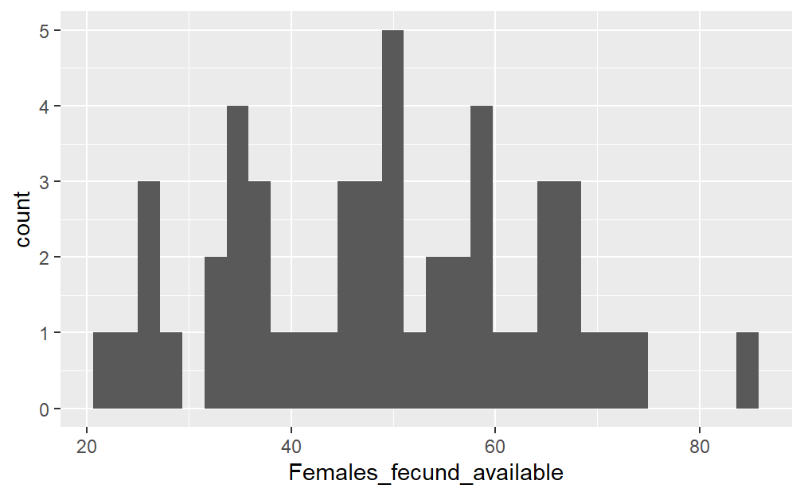

```r
library(tidyverse)
library(here)

orcaCensus <- read.csv(here("NRKW Population 1.csv"))
#orcapop<-read.csv("C:/Users/Owner/Desktop/fall 23'/EEB 313/NRKW Population 1.csv")

library(ggplot2)

ggplot(data = orcapop, aes(x = Females_fecund_available)) +
  geom_histogram()
```

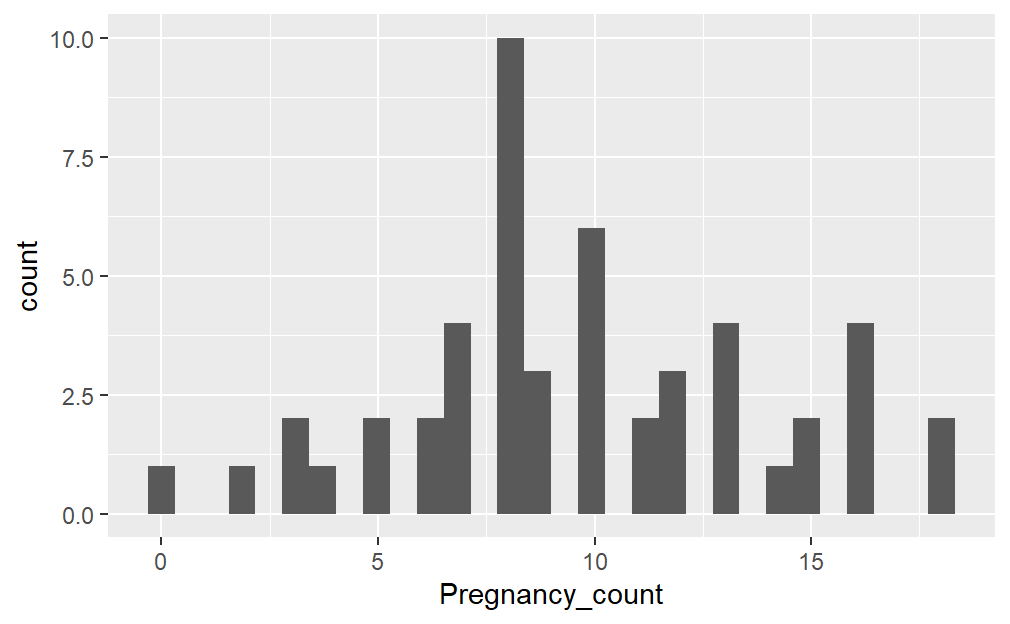

```r
ggplot (data = orcapop, aes(x = Pregnancy_count)) +
  geom_histogram()
```

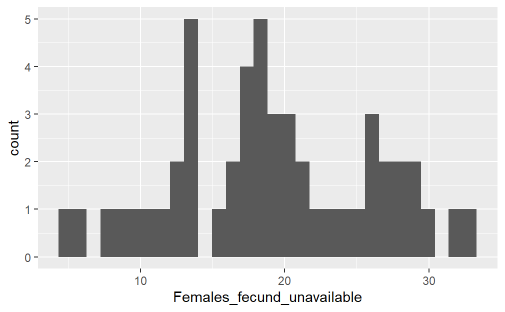

```r
#measure of lactating

ggplot(data = orcapop, aes(x = Females_fecund_unavailable)) +
  geom_histogram()
```

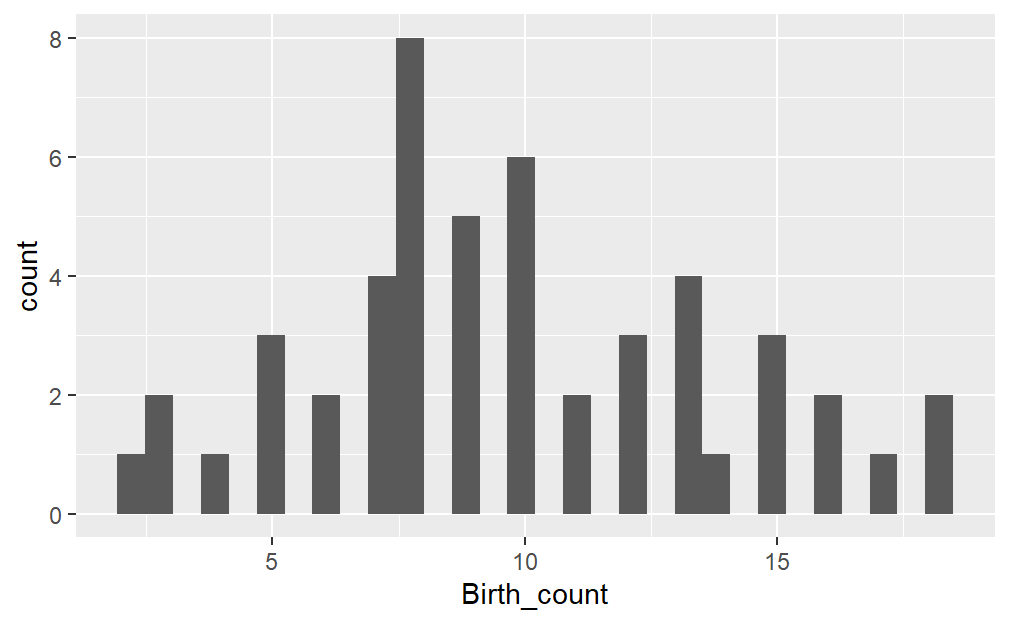

```r
ggplot(data = orcapop, aes(x = Birth_count)) +
  geom_histogram()
```

```r
NA
NA
```

## Orca Data Wrangling

```r
# (val - mean) / 2*SD
# mean_Size <- mean(orcaCensus$Size_best)
# sd_Size <- sd(orcaCensus$Size_best)
# transformed_Total <- (orcaCensus$Size_best-mean_Size)/(2*sd_Size)
# untransformed_Group_Num <- NULL
# for(i in 1:564){
#   untransformed_Group_Num[i] <- (orca_data$Ng[i]*(2*sd_Size))+mean_Size
# }
# mean_Fecund_Unav <- mean(orcaCensus$Females_fecund_unavailable)
# sd_Fecund_Unav <- sd(orcaCensus$Females_fecund_unavailable)
# untransformed_FLg <- NULL
# for(i in 1:564){
#   untransformed_FLg[i] <- (orca_data$FLg[i]*(2*sd_Fecund_Unav))+mean_Fecund_Unav
# }
#untransformed_Group_Num <- (orca_data$Ng/sD_Size)+mean_Size
# THIS GIRL SHOUD NEVER WRITE A PAPER AGAIN

# pods_mod_Data_Year <- data.frame()
# for(i in 1:31){
#   year <- i+1979
#   pods_mod_Data_Year[i,1] <- year
#   pods_mod_Data_Year[i,2] <- orca_data %>% tally(Year == year)
#   pods_mod_Data_Year[i,3] <- (orcaCensus$Size_best[orcaCensus$YEAR==(year)]
#                               /pods_mod_Data_Year[i,2])
# }
# colnames(pods_mod_Data_Year) <- c("Year", "Measured_Pod_Count",
#                                   "Avg_Orcas_Per_Pod")

pods_Census_Data <- data.frame()
pods_List <- c(20,18,18,20,21,17,16,21,21,20,21,20,24,26,25,25,
               25,25,24,25,25,25,24,21,22,23,23,25,25,23,24)
for(i in 1:31){
  year <- i+1979
  pods_Census_Data[i,1] <- year
  pods_Census_Data[i,2] <- pods_List[i]
  pods_Census_Data[i,3] <- (orcaCensus$Size_best[orcaCensus$YEAR==(year)]
                            /pods_List[i])
  pods_Census_Data[i,4] <-
    (orcaCensus$Females_fecund_unavailable[orcaCensus$YEAR==(year)]
                            /pods_List[i])
}
colnames(pods_Census_Data) <- c("Year", "Pod_Count",
                                "Avg_Orcas_Per_Pod", "Avg_Fecund_Unav_Per_Pod")

pods_Data <- data.frame() # create a data frame to hold the estimated pod data
x <- 1
i <- 1
while(x < 692){
  year <- i+1979
  pods_Data[c(x:((x-1)+pods_List[i])),1] <- year # add the year for each row
  pods_Data[c(x:((x-1)+pods_List[i])),2] <- c(1:pods_List[i]) #add a pod number
  x <- x+pods_List[i]
  i <- i+1
}
# Old pod size and lact female calculations
# probabs <- c(0.025, 0.05, 0.075, 0.175, 0.35, 0.175, 0.075, 0.05, 0.025)
# for(x in 1:nrow(pods_Census_Data)){
#   year <- x+1979
#   for(i in x:((x-1)+pods_List[x])){
#     # use a poisson distribution to get a number of orcas in each pod based
#     # on the average number of orcas in each pod that year
#     pods_Data[i,3] <- rpois(1, pods_Census_Data[x,3])
#     #multiNom_Pod_Size <- rmultinom(1, size = s_Total, prob = rep(1,pods_List[x]))
#     #pods_Data[i,4] <- rmultinom(1, size = s_Total, prob = rep(1,pods_List[x]))
#     pods_Data[i,4] <- rpois(1, pods_Census_Data[x,4])
#     #pods_Data[i,6] <- rmultinom(1, size = s_Lact, prob = rep(1,pods_List[x]))
#     # mean_Size <- round(pods_Census_Data[x,3])
#     # pods_Data[i,3] <- sample(c((mean_Size-4):(mean_Size+4)), 1, replace = T, prob = probabs)
#   }
# }
colnames(pods_Data) <- c("Year", "Pod_Num")

pod_Multinom_Sizes <- data.frame()
n <- 31
for(i in 1:n){ #generate pod sizes
  year <- i+1979
  s_Total <- orcaCensus$Size_best[orcaCensus$YEAR==year]
  s_Fecund_Unav <- orcaCensus$Females_fecund_unavailable[orcaCensus$YEAR==year]
  s_Births <- orcaCensus$Birth_count[orcaCensus$YEAR==year]
  s_Pregnancy <- orcaCensus$Pregnancy_count[orcaCensus$YEAR==year]

  size_Pod <- rmultinom(1, size = s_Total,
                        prob = rep(1,pods_List[i]))
  size_Fecund_Unav_Pod <- rmultinom(1, size = s_Fecund_Unav,
                                    prob = rep(1,pods_List[i]))
  size_Births_Pod <- rmultinom(1, size = s_Births,
                                    prob = rep(1,pods_List[i]))
  size_Pregnancy_Pod <- rmultinom(1, size = s_Pregnancy,
                                    prob = rep(1,pods_List[i]))

  pod_size_by_group <- data.frame(year, size_Pod, size_Fecund_Unav_Pod,
                                  size_Births_Pod, size_Pregnancy_Pod)

  pod_Multinom_Sizes <- rbind(pod_Multinom_Sizes, pod_size_by_group)
}

pods_Data <- pods_Data %>% mutate(Pod_Size_Multinom =
                                    pod_Multinom_Sizes$size_Pod)
pods_Data <- pods_Data %>% mutate(Fecund_Unav_Multinom =
                                    pod_Multinom_Sizes$size_Fecund_Unav_Pod)
pods_Data <- pods_Data %>% mutate(Births_Multinom =
                                    pod_Multinom_Sizes$size_Births_Pod)
pods_Data <- pods_Data %>% mutate(Pregnancy_Multinom =
                                    pod_Multinom_Sizes$size_Pregnancy_Pod)
```

|  | Year | Pod_Num | Pod_Size_Multinom | Fecund_Unav_Multinom | Births_Multinom | Pregnancy_Multinom |
| --- | --- | --- | --- | --- | --- | --- |
| 1 | 1980 | 1 | 6 | 0 | 1 | 0 |
| 2 | 1980 | 2 | 3 | 0 | 1 | 0 |
| 3 | 1980 | 3 | 12 | 1 | 0 | 1 |
| 4 | 1980 | 4 | 8 | 1 | 0 | 0 |
| 5 | 1980 | 5 | 8 | 2 | 1 | 0 |
| 6 | 1980 | 6 | 6 | 0 | 2 | 0 |
| 7 | 1980 | 7 | 6 | 1 | 0 | 1 |
| 8 | 1980 | 8 | 4 | 1 | 0 | 0 |
| 9 | 1980 | 9 | 6 | 2 | 0 | 1 |
| 10 | 1980 | 10 | 8 | 0 | 0 | 0 |

[output cut: 682 more lines]

## GLMM/LMM

### Checking Assumptions

```r
hist(pods_Salmon_Data$Fecund_Unav_Multinom)
hist(pods_Salmon_Data$Births_Multinom)
hist(pods_Salmon_Data$Pregnancy_Multinom)
hist(pods_Salmon_Data$Pod_Size_Multinom)
hist(pods_Salmon_Data$Total_Salmon)
# Fecundity unavialable, births, pregnancy is not normal, so GLMM
```

### Pod Model

```r
pod_Fecund_Unav_Model <- glmer(Fecund_Unav_Multinom~Total_Salmon+Pod_Size_Multinom+
                   (1|Pod_Num)+(1|Year),
                 family = poisson, pods_Salmon_Data)
summary(pod_Fecund_Unav_Model)

pod_Births_Model <- glmer(Births_Multinom~Total_Salmon+Pod_Size_Multinom+
                   (1|Pod_Num)+(1|Year),
                 family = poisson, pods_Salmon_Data)
summary(pod_Births_Model)

pod_Pregnancy_Model <- glmer(Pregnancy_Multinom~Total_Salmon+Pod_Size_Multinom+
                   (1|Pod_Num)+(1|Year),
                 family = poisson, pods_Salmon_Data)
summary(pod_Pregnancy_Model)
```

*Note*: I’m not sure how to graph this lol i tried and failed

### Total Population Model

I’m gonna see if just looking at the population as a whole matters

```r
by_Year_Salmon <- orcaCensus %>% filter(YEAR >= 1980 & YEAR <= 2010)
by_Year_Salmon <- by_Year_Salmon %>% select(YEAR, Size_best,
                                            Females_fecund_unavailable,
                                            Birth_count, Pregnancy_count)
by_Year_Salmon <- by_Year_Salmon %>% mutate(chinook_abundance =
                                              salmon_data$chinook_density)
by_Year_Salmon <- by_Year_Salmon %>% mutate(chum_abundance =
                                              salmon_data$chum_density)
by_Year_Salmon <- by_Year_Salmon %>% mutate(total_salmon =
                                              salmon_data$total_salmon)

pop_Fecund_Unav_Model <- glmer(Females_fecund_unavailable~total_salmon+
                                 Size_best+(1|YEAR),
                 family = poisson, by_Year_Salmon)
summary(pop_Fecund_Unav_Model)

pop_Births_Model <- glmer(Birth_count~total_salmon+
                            Size_best+(1|YEAR),
                 family = poisson, by_Year_Salmon)
summary(pop_Births_Model)

pop_Pregnancy_Model <- glmer(Pregnancy_count~total_salmon+
                            Size_best+(1|YEAR),
                 family = poisson, by_Year_Salmon)
summary(pop_Pregnancy_Model)
```

Pod Counts Per Year: (From Fig. 1c) 1980: 20 pods 1981: 18 pods 1982: 18 pods 1983: 20 pods 1984: 21 pods 1985: 17 pods 1986: 16 pods 1987: 21 pods 1988: 21 pods 1989: 20 pods 1990: 21 pods 1991: 20 pods 1992: 24 pods 1993: 26 pods 1994: 25 pods 1995: 25 pods 1996: 25 pods 1997: 25 pods 1998: 24 pods 1999: 25 pods 2000: 25 pods 2001: 25 pods 2002: 24 pods 2003: 21 pods 2004: 22 pods 2005: 23 pods 2006: 23 pods 2007: 25 pods 2008: 25 pods 2009: 23 pods 2010: 24 pods

Models without salmon

```r
Fecund_Unav_Model <- glmer(Fecund_Unav_Multinom~Pod_Size_Multinom+
                   (1|Pod_Num)+(1|Year),
                 family = poisson, pods_Salmon_Data)
summary(Fecund_Unav_Model)
```

```
Generalized linear mixed model fit by maximum likelihood
  (Laplace Approximation) [glmerMod]
 Family: poisson  ( log )
Formula:
Fecund_Unav_Multinom ~ Pod_Size_Multinom + (1 | Pod_Num) + (1 |
    Year)
   Data: pods_Salmon_Data

     AIC      BIC   logLik deviance df.resid
  1691.6   1709.7   -841.8   1683.6      688

Scaled residuals:
    Min      1Q  Median      3Q     Max
-1.1048 -0.8744  0.0618  0.3609  3.9201

Random effects:
 Groups  Name        Variance Std.Dev.
 Year    (Intercept) 0.02841  0.1686
 Pod_Num (Intercept) 0.02847  0.1687
Number of obs: 692, groups:  Year, 31; Pod_Num, 26

Fixed effects:
                  Estimate Std. Error z value Pr(>|z|)
(Intercept)       -0.26269    0.13726  -1.914   0.0556 .
Pod_Size_Multinom  0.01040    0.01366   0.761   0.4466
---
Signif. codes:
0 ‘***’ 0.001 ‘**’ 0.01 ‘*’ 0.05 ‘.’ 0.1 ‘ ’ 1

Correlation of Fixed Effects:
            (Intr)
Pd_Sz_Mltnm -0.891
```

```r
Births_Model <- glmer(Births_Multinom~Pod_Size_Multinom+
                   (1|Pod_Num)+(1|Year),
                 family = poisson, pods_Salmon_Data)
```

```
boundary (singular) fit: see help('isSingular')
```

```r
summary(Births_Model)
```

```
Generalized linear mixed model fit by maximum likelihood
  (Laplace Approximation) [glmerMod]
 Family: poisson  ( log )
Formula:
Births_Multinom ~ Pod_Size_Multinom + (1 | Pod_Num) + (1 | Year)
   Data: pods_Salmon_Data

     AIC      BIC   logLik deviance df.resid
  1197.7   1215.9   -594.9   1189.7      688

Scaled residuals:
    Min      1Q  Median      3Q     Max
-0.7183 -0.6607 -0.6421  0.8284  5.3534

Random effects:
 Groups  Name        Variance  Std.Dev.
 Year    (Intercept) 1.403e-02 1.185e-01
 Pod_Num (Intercept) 1.923e-10 1.387e-05
Number of obs: 692, groups:  Year, 31; Pod_Num, 26

Fixed effects:
                  Estimate Std. Error z value Pr(>|z|)
(Intercept)       -0.93010    0.17890  -5.199    2e-07 ***
Pod_Size_Multinom  0.01114    0.01885   0.591    0.555
---
Signif. codes:
0 ‘***’ 0.001 ‘**’ 0.01 ‘*’ 0.05 ‘.’ 0.1 ‘ ’ 1

Correlation of Fixed Effects:
            (Intr)
Pd_Sz_Mltnm -0.936
optimizer (Nelder_Mead) convergence code: 0 (OK)
boundary (singular) fit: see help('isSingular')
```

```r
Pregnancy_Model <- glmer(Pregnancy_Multinom~Pod_Size_Multinom+
                   (1|Pod_Num)+(1|Year),
                 family = poisson, pods_Salmon_Data)
summary(Pregnancy_Model)
```

[output not shown]